# Trail Lecture

Code Tasks

Author

Affiliation

Dejene Gizaw Kidane

[UiT The Arctic University of Norway](https://uit.no/ansatte/dejene.g.kidane)

Published

January 25, 2023

# Task 1: Polynomial regression model

- The first task given to work with is a polynomial regression model.
- Polynomial regression is considered to be a special case of multiple linear regression model.
- It models the relationship b/n the $x$ & $y$ variables by $k^{th}$ degree polynomial in $x$.
- It fits a nonlinear relationship b/n the value of $x$ and the conditional mean of $y$.

A $k^{th}$ order polynomial model can be given as follows:

$$y = \alpha + \sum_{i=1}^k\beta_i x^i$$

Iterating this model for $i = 1,2,...,k$, we will have the following $k$ polynomial regression models:

$$y = \alpha + \beta_1x^1$$
$$y = \alpha + \beta_1x^1 + \beta_2x^2 \\
...$$
$$y = \alpha + \beta_1x^1 + \beta_2x^2 + ...+\beta_kx^k$$

- Now let us look at:
  - how to best fit polynomial regression models using a data.
  - how to select the best model
  - I will be using a data scraped from the [web-page](https://www.nettavisen.no/skattetall/penger/skattelistene-2022/stor-oversikt-dette-er-snittlonnen-for-ditt-arskull-pa-ditt-postnummer/s/5-95-806984).
  - The table contains data of taxpayers average income & wealth per birth year in Norway, from 1917 to 2003.
  - So, let us first scrap the table from the webpage.

```r
# first load relevant packages and libraries to scrap the data and perform the analysis
rm(list = ls())
library(tidyverse)
library(janitor)
library(lubridate)
library(forecast)
library(quantmod)
library(furrr)
library(tibble)
library(tsibble)
library(mosaic)
library(rvest)
#library(fable)
```

## Web scraping

- We can use R code to scrape this table from the web.
- We can use the **rvest** package to scrape the **html** page of the table.

```r
# URl of the data
url <- "https://www.nettavisen.no/skattetall/penger/skattelistene-2022/stor-oversikt-dette-er-snittlonnen-for-ditt-arskull-pa-ditt-postnummer/s/5-95-806984"

url %>% read_html() %>%
  html_elements("table") %>%
  html_table()
```

```
list()
```

- **Empty list!**. So how can get the table?
- Hover over the html page, we can see that the table is  
  embedded in an **iframe tag**.
- In this tag, we can get the hidden datawrapper link of the data.
- Get the datawrapper link (this link starts with src), and open it in new window.
- Then press **F12**. That will open **DevTools** of the table.
- Then find the **.csv** file from this page by pressing the keyboard **Ctrl + R**.
- The following code then read the **.csv** file of the data.

```r
##Read data from the csv file of the data and look at the structure
raw_dataset <- read_csv("https://datawrapper.dwcdn.net/sBuxT/3/dataset.csv")
str(raw_dataset)
```

```
spc_tbl_ [977 × 8] (S3: spec_tbl_df/tbl_df/tbl/data.frame)
 $ birthyr             : num [1:977] 1917 1918 1919 1920 1921 ...
 $ n_taxpayers         : num [1:977] 53 76 162 257 420 ...
 $ income              : num [1:977] 110184 118620 139005 165488 169149 ...
 $ fortune             : num [1:977] 495961 637675 886737 793308 915451 ...
 $ n_millionincome     : num [1:977] 1 0 1 1 2 1 2 3 7 15 ...
 $ n_millionfortune    : num [1:977] 11 19 41 71 128 ...
 $ Andel millioninntekt: chr [1:977] "1.89%" "0.00%" "0.62%" "0.39%" ...
 $ Andel millionformue : chr [1:977] "20.75%" "25.00%" "25.31%" "27.63%" ...
 - attr(*, "spec")=
  .. cols(
  ..   birthyr = col_double(),
  ..   n_taxpayers = col_number(),
  ..   income = col_number(),
  ..   fortune = col_number(),
  ..   n_millionincome = col_number(),
  ..   n_millionfortune = col_number(),
  ..   `Andel millioninntekt` = col_character(),
  ..   `Andel millionformue` = col_character()
  .. )
 - attr(*, "problems")=<externalptr>
```

- The data frame contains eight variables.
- However, the focus here is to work on birthyr & share of million wealth.
- We only focus on the share of taxpayers that has wealth  
  over 1 million NOK, measured as percentage points (as $y$- variable), and
- Birth year( as $x$-variable).
- So, start by cleaning the data and defining the new -  
  variables.

```r
#clean the data frame using the fun called "clean_names"
#from the "janitor" package.
dataset <-
  raw_dataset %>%
  clean_names()

#Filtering to make sure we do not have text at the end
dataset <-
  dataset %>%
  filter(birthyr <= 2003)

# Define the new variables
dataset <-
  dataset %>%
  mutate(share_mill_inc = 100*n_millionincome/n_taxpayers,
         share_mill_wealth = 100*n_millionfortune/n_taxpayers)
#head(dataset)
#tail(dataset)
```

- Ploting birth year versus share of taxpayers with million wealth.

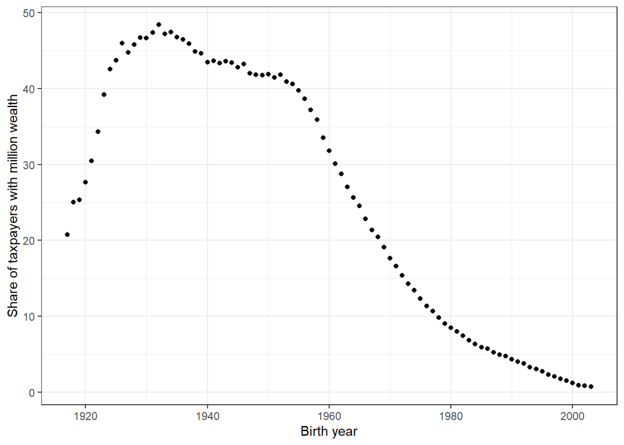

```r
dataset %>%
  ggplot(aes(x=birthyr, y=share_mill_wealth)) +
  geom_point() +
  xlab("Birth year") +
  ylab("Share of taxpayers with million wealth") +
  theme_bw()
```

- It is obvious that the plot above is non-linear.
- Now let us fit the data using the polynomial regression model of degree $k = 1,2,...,12$.
- And then choose the best model that minimizes the AIC  
  value out of these $12$ estimated regression models.

## Fitting the data and selecting the best model

- I used for loop to iterate and fit the data using  
  polynomial of order $i = 1, 2, ..., 12$.
- Since the issue of multicollinearity is one challenge in polynomial regression modeling,
- I used **orthogonal polynomial fitting** using the **poly** function in R.
- AIC information criteria to select the best model out of the 12 estimated models.

```r
# First renaming variables for simplicity(defining the x and y variables)
dataset <- dataset %>%
  select(birthyr,share_mill_wealth) %>%
  rename(x = birthyr,
         y = share_mill_wealth)

#Run for loop to estimate models and store model information as output.
# setup
k <- c(1:12) # k-th order
AIC <- data.frame("kth_order" = NA, "AIC" = NA) # empty data frame to store AIC
RMSE <- data.frame("kth_order" = NA, "RMSE" = NA) # empty data frame to store RMSE

for (i in 1:length(k)) {
  # build models
  model <- lm(y ~ poly(x, k[i]), data = dataset) # the fun poly allows to use orthogonal polynomial to avoid the issue of multicollinearity

  # calculate RMSE and store it for further usage
  RMSE[i, 1] <- k[i] # store k-th order for RMSE
  RMSE[i, 2] <- sqrt(mean((fitted(model) - dataset$y)^2))
  AIC[i,1] <- k[i] # store k-th order for AIC
  AIC[i,2] <- AIC(model)
}
# output from the loop
output <- data.frame(RMSE, AIC=AIC$AIC)
output
```

```
   kth_order      RMSE      AIC
1          1 8.2559956 620.1988
2          2 6.4926059 580.3908
3          3 2.1238818 387.9600
4          4 1.8790063 368.6446
5          5 1.8783339 370.5823
6          6 1.4134256 323.1021
7          7 1.3094836 311.8114
8          8 1.0304815 272.1199
9          9 0.6643752 197.7453
10        10 0.6449433 194.5801
11        11 0.6239779 190.8299
12        12 0.6235005 192.6967
```

- Now choose the best model based.
- The best model is considered to be the one with the  
  lowest AIC.

```r
#best model based on AIC
output%>%
  filter(AIC==min(AIC))
```

```
  kth_order      RMSE      AIC
1        11 0.6239779 190.8299
```

- Estimate the best model, and
- check whether AIC and RMSE are consistent with what we have got above.

```r
# the poly 11 model is the smallest
fit <- lm(y ~ poly(x, 11 , raw=FALSE), data = dataset)
AIC(fit)
```

```
[1] 190.8299
```

```r
#plotModel(fit)

# check (calculate the RMSE of the best model)
dataset <- dataset %>% mutate(y_hat=predict(fit))
dataset %>% summarise(RMSE=sqrt(mean((y-y_hat)^2)))
```

```
# A tibble: 1 × 1
   RMSE
  <dbl>
1 0.624
```

```r
library(Metrics)
RMSE <- round(rmse(dataset$y, dataset$y_hat),4)
RMSE #the same as above
```

```
[1] 0.624
```

- Make a plot of the “best” model from above and include data points.
- Restrict the observations on the plot and the fitted model such that **birth year** is in the interval $\{1925 \leq x \leq 2000\}.$
- Add the **RMSE** to the plot.

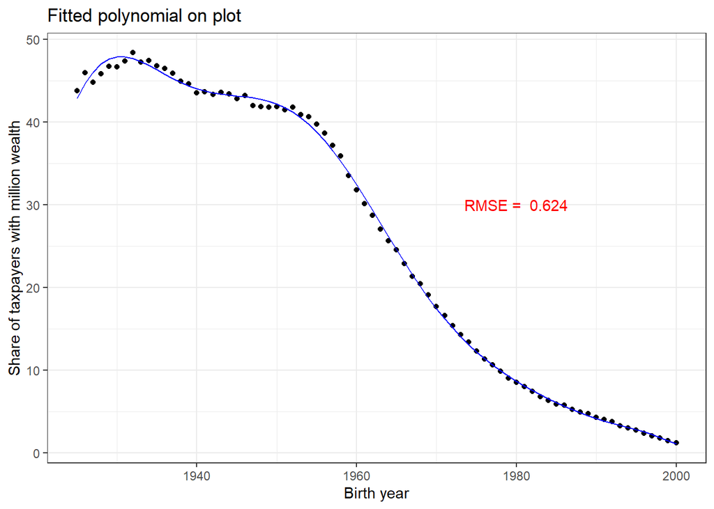

```r
# plot the best model
library(ggrepel)
dataset %>%
  mutate(predicted=predict(fit)) %>%
  filter(x>= 1925 & x <= 2000) %>%
  ggplot(aes(x=x,y=y)) +
  geom_point() +
  geom_line(aes(x=x,y=predicted), col="blue") +
  xlab("Birth year") +
  ylab("Share of taxpayers with million wealth") +
  annotate(geom="text", x=1980, y=30, label=paste("RMSE = ", RMSE), color="red") +
  ggtitle("Fitted polynomial on plot") +
  theme_bw()
```

# Task 2- Time series analsysis using ARIMA model - accuracy in forecasting

- In time series analysis we often want to predict something (e.g., sales, prices, etc.) in the future on the basis of what we have observed in the past.
- A popular and very widely used statistical method for time series forecasting and analysis is the ARIMA model. **ARIMA** is an acronym that stands for **autoregressive integrated moving average model**.
- As the name suggests, **ARIMA** model combine three different techniques:
  - autoregression,
  - integration(differencing), and
  - moving average.
- The components make the model work using three parameters denoted by $(p,d,q)$,and they are called the order of ARIMA model.
- For instance, given a time series data $X_t$, ARIMA model exhibiting an order $(p,d,q)$ can be given as:

$$X_t = a_1X_{t-1} + ...+a_pX_{t-p} + \epsilon_t + b_1\epsilon_{t-1}+...+b_q\epsilon_{t-q}$$
where;

- $p$ - order of the autoregressive (**AR**) part of the model,
- $d$ - degree of differencing involved to make the  
  time-series stationary,
- $q$ - order of the moving average (**MA**) part, and

$a_i$ & $b_i$ - are the parameters of the model,  
$\epsilon_t$ are error terms ($\epsilon_t \sim i.i.d$).

**The Task:**

- The exercise here is to model stock prices from **Exxon Mobile Corporation (XOM)**, traded at NYSE.The XOM stock prices is obtained from [The Yahoo! Fiance site](https://finance.yahoo.com/quote/XOM?p=XOM&.tsrc=fin-srch&guccounter=1).
- Two model specifications of a non-seasonal **ARIMA**  
  models are estimated.
  - In **model-1**, a univariate ARIMA model is estimated.
  - In **model-2**, the **Brent Crude Oil Price** is used as an  
    explanatory variable. The Brent Crude Oil Price is  
    obtained from [FRED](https://fred.stlouisfed.org/series/DCOILBRENTEU).

```r
# Import XOM data from yahoo finance

loadSymbols("XOM", src="yahoo" )
```

```
[1] "XOM"
```

```r
xom_data <- XOM
head(xom_data)
```

```
           XOM.Open XOM.High XOM.Low XOM.Close XOM.Volume XOM.Adjusted
2007-01-03    76.26    76.27   73.51     74.11   30510700     42.43665
2007-01-04    73.85    73.90   72.21     72.72   31046600     41.64070
2007-01-05    72.45    73.38   72.22     73.24   24671500     41.93846
2007-01-08    73.88    74.25   71.85     72.65   25981900     41.60063
2007-01-09    71.85    72.84   71.44     72.09   27039900     41.27995
2007-01-10    71.81    73.11   70.64     70.99   30572000     40.65006
```

```r
class(xom_data) # this is xts or zoo
```

```
[1] "xts" "zoo"
```

```r
# convert it to a data frame
xom.df <- as.data.frame(xom_data)  #data frame
class(xom.df)
```

```
[1] "data.frame"
```

```r
head(xom.df)
```

```
           XOM.Open XOM.High XOM.Low XOM.Close XOM.Volume XOM.Adjusted
2007-01-03    76.26    76.27   73.51     74.11   30510700     42.43665
2007-01-04    73.85    73.90   72.21     72.72   31046600     41.64070
2007-01-05    72.45    73.38   72.22     73.24   24671500     41.93846
2007-01-08    73.88    74.25   71.85     72.65   25981900     41.60063
2007-01-09    71.85    72.84   71.44     72.09   27039900     41.27995
2007-01-10    71.81    73.11   70.64     70.99   30572000     40.65006
```

```r
#Import the Brent Crude oil price from FRED

loadSymbols("DCOILBRENTEU", src="FRED")
```

```
[1] "DCOILBRENTEU"
```

```r
#getSymbols("DCOILBRENTEU", src = "FRED",from ="2010-01-04", to = "2022-01-13")
oil_data <- DCOILBRENTEU
class(oil_data) # this is xts or zoo
```

```
[1] "xts" "zoo"
```

```r
# convert it to a data frame
oil_df <- as.data.frame(oil_data)
class(oil_df)
```

```
[1] "data.frame"
```

```r
head(oil_df)
```

```
           DCOILBRENTEU
1987-05-20        18.63
1987-05-21        18.45
1987-05-22        18.55
1987-05-25        18.60
1987-05-26        18.63
1987-05-27        18.60
```

## Data Wrangling

```r
# calculate the monthly arithmetic average of xom price data.
# Also calculate the weighted average of xom, using volume traded as a weight.
xom <- xom.df %>%
  mutate(Date = ymd(rownames(xom.df))) %>% # create a date variable from the row names
  filter(Date >="2010-01-04",Date<"2023-01-01") %>%  # filter data only between the specified dates
  mutate(year = year(Date), #create the variable called year from the date variable
         month = month(Date), #create the variable month from the date variable
         day = day(Date)) %>% #create the variables day from the date variable
  group_by(year,month) %>%
  # calculate arithmetic average of xom.adjusted
  summarise(xom_monthly_art= mean(XOM.Adjusted),
    #calculate weighted average using volume as a weight.
            xom_monthly_wt=sum(XOM.Adjusted*XOM.Volume)/sum(XOM.Volume)) %>%
  mutate(date = make_date(year,month,1)) %>% as_tibble() %>%  # make the date variable, setting all day's as first day
  select(date, xom_monthly_wt)

#output
xom
```

```
# A tibble: 156 × 2
   date       xom_monthly_wt
   <date>              <dbl>
 1 2010-01-01           41.2
 2 2010-02-01           39.9
 3 2010-03-01           40.7
 4 2010-04-01           41.8
 5 2010-05-01           38.6
 6 2010-06-01           37.1
 7 2010-07-01           36.2
 8 2010-08-01           37.4
 9 2010-09-01           38.0
10 2010-10-01           40.3
# … with 146 more rows
```

```r
# calculate the monthly arithmetic average of oil price data.
oil <- oil_df %>%
  # create a date variable from the rownames of the dataframe
  mutate(Date = ymd(rownames(oil_df))) %>%
  # filter the data only between 2010-01-04 and 2022-12-30
  # since our package imports all data from 1987-05-20
  filter(Date>="2010-01-04",Date<"2023-01-01") %>%
  mutate(year = year(Date),
         month = month(Date),
         day = day(Date)) %>%
  group_by(year,month) %>%
  # calculate the monthly arithmetic average
  summarise(oil_monthly= mean(DCOILBRENTEU, na.rm = TRUE)) %>%
  mutate(date = make_date(year,month,1)) %>%as_tibble() %>%  # make the date variable, setting all day's as first day
  select(date,oil_monthly)
#output
oil
```

```
# A tibble: 156 × 2
   date       oil_monthly
   <date>           <dbl>
 1 2010-01-01        76.2
 2 2010-02-01        73.8
 3 2010-03-01        78.8
 4 2010-04-01        84.8
 5 2010-05-01        75.9
 6 2010-06-01        74.8
 7 2010-07-01        75.6
 8 2010-08-01        77.0
 9 2010-09-01        77.8
10 2010-10-01        82.7
# … with 146 more rows
```

```r
# Combine/merge the xom and oil data as one data frame, and rename variables.

dframe <- xom %>% left_join(oil) # combine the two dataframe as one

dframe <- dframe%>%
  rename(exxon=xom_monthly_wt,  #rename variables from simplicity
         brent = oil_monthly)
head(dframe)
```

```
# A tibble: 6 × 3
  date       exxon brent
  <date>     <dbl> <dbl>
1 2010-01-01  41.2  76.2
2 2010-02-01  39.9  73.8
3 2010-03-01  40.7  78.8
4 2010-04-01  41.8  84.8
5 2010-05-01  38.6  75.9
6 2010-06-01  37.1  74.8
```

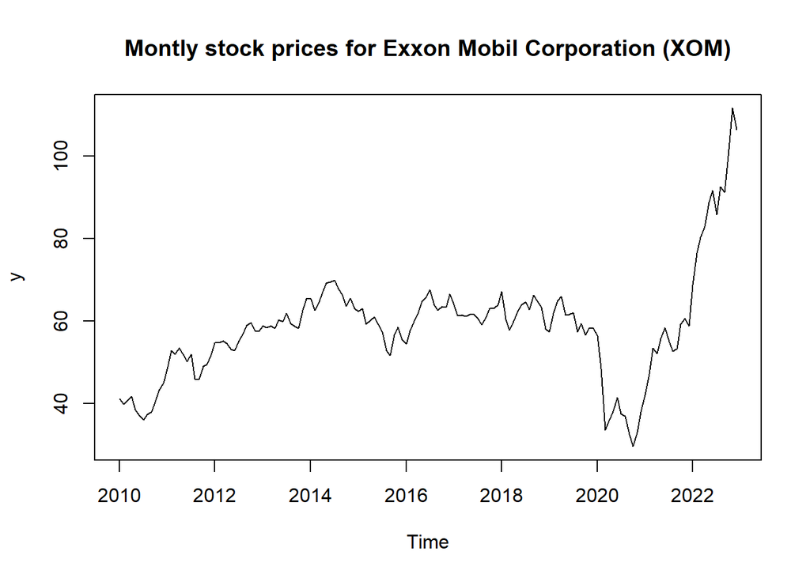

```r
# define the variables as time series objects.
# assign them as y and x variables, and time series plots.
y <-
  dframe %>%
  mutate(y=exxon,
         year=year(date)) %>%  # create the year variable from the date variable
  filter(year <= 2022) %>%
  select(y) %>%
  ts(., frequency = 12, start = c(2010, 1)) # use ts() fun to define y as a time series variable

plot(y,main="Montly stock prices for Exxon Mobil Corporation (XOM)")
```

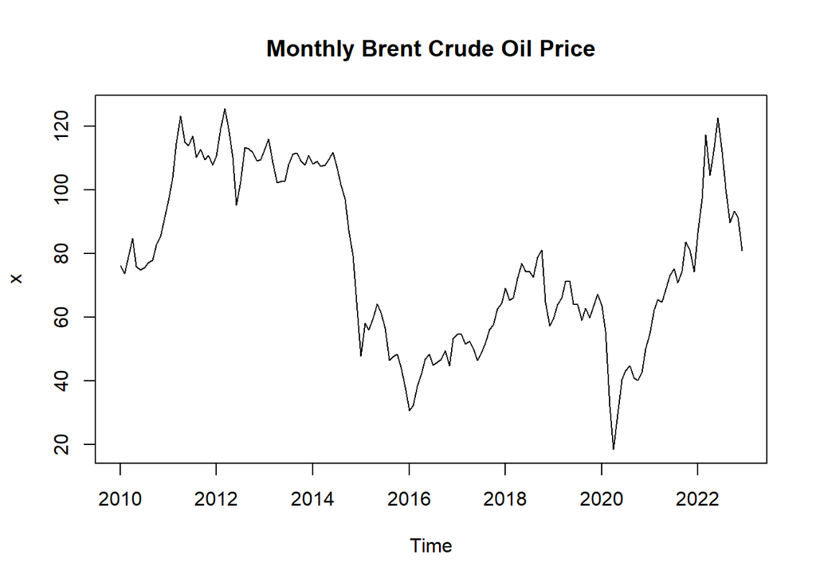

```r
x <-
  dframe %>%
  mutate(x=brent,
         year=year(date)) %>%
  filter(year <= 2022) %>%
  select(x) %>%
  ts(., frequency = 12, start = c(2010, 1)) # use ts() fun to define x as a time series variable

plot(x,main="Monthly Brent Crude Oil Price")
```

- The ARIMA models work on the ideal assumption of the data being stationary.Stationary variable is a variable whose mean and variance do not change over time.
- Looking at the plots of the series above, we can understand that the dataset are non-stationary. However, we can make these variables stationary by taking the first differences of the variables.

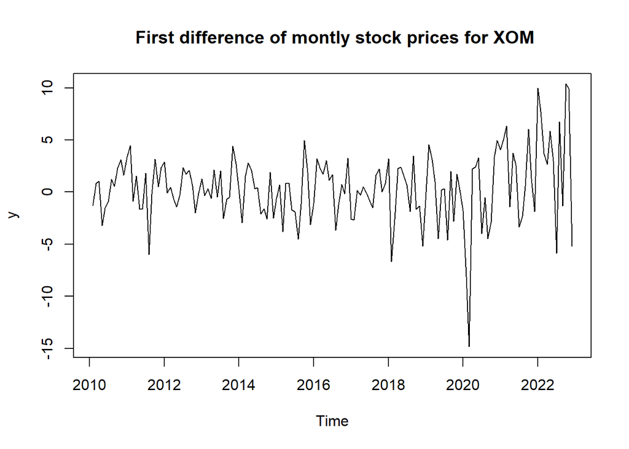

```r
# plots of the first difference of x and y
plot(diff(y),main=" First difference of montly stock prices for XOM")
```

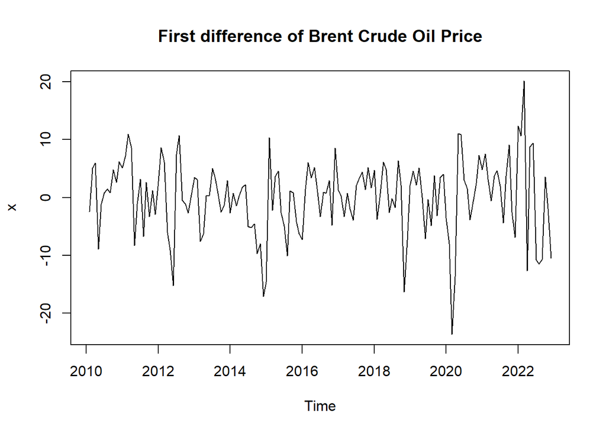

```r
plot(diff(x),main="First difference of Brent Crude Oil Price")
```

- The stationarity of the data the data can be checked using the Augmented Dickey-Fuller (ADF) test.
- If the p-value of the test is more than the significance level then we consider time series data as nonstationary and if it is not then the time series is stationary.

```r
# Unit root test - ADF test
# both x and y are non-stationary in levels
library(tseries)
adf.test(x)
```

```
    Augmented Dickey-Fuller Test

data:  x
Dickey-Fuller = -2.1747, Lag order = 5, p-value = 0.5035
alternative hypothesis: stationary
```

```r
adf.test(y)
```

```
    Augmented Dickey-Fuller Test

data:  y
Dickey-Fuller = -1.2184, Lag order = 5, p-value = 0.9008
alternative hypothesis: stationary
```

```r
# ADF test on differenced variables
# both x and y are stationary in first difference
adf.test(diff(x))
```

```
    Augmented Dickey-Fuller Test

data:  diff(x)
Dickey-Fuller = -4.9643, Lag order = 5, p-value = 0.01
alternative hypothesis: stationary
```

```r
adf.test(diff(y))
```

```
    Augmented Dickey-Fuller Test

data:  diff(y)
Dickey-Fuller = -4.3213, Lag order = 5, p-value = 0.01
alternative hypothesis: stationary
```

```r
#Split the x and y variables as train and test data
y_train <- window(y, end=c(2022, 6))
y_test <- window(y, start=c(2022, 7))

x_train <- window(x, end=c(2022, 6))
x_test <- window(x, start=c(2022, 7))
```

## Estimation

### Using **auto.arima()** function

- Estimate ARIMA model using **auto.arima** function from the *forecast* package.
- The **auto.arima** function finds the best model based on Akaike Information Criteria (AIC).

```r
# AIC in train, Model 2, slightly better & a simple structure
# Model 1
mod_1 <- forecast::auto.arima(y_train)
mod_1
```

```
Series: y_train
ARIMA(0,1,1)

Coefficients:
        ma1
      0.302
s.e.  0.078

sigma^2 = 8.708:  log likelihood = -372.21
AIC=748.41   AICc=748.5   BIC=754.42
```

```r
# Model 2
mod_2 <- forecast::auto.arima(y_train, xreg = x_train)
mod_2
```

```
Series: y_train
Regression with ARIMA(0,1,0) errors

Coefficients:
           x
      0.2869
s.e.  0.0320

sigma^2 = 6.182:  log likelihood = -346.63
AIC=697.27   AICc=697.35   BIC=703.28
```

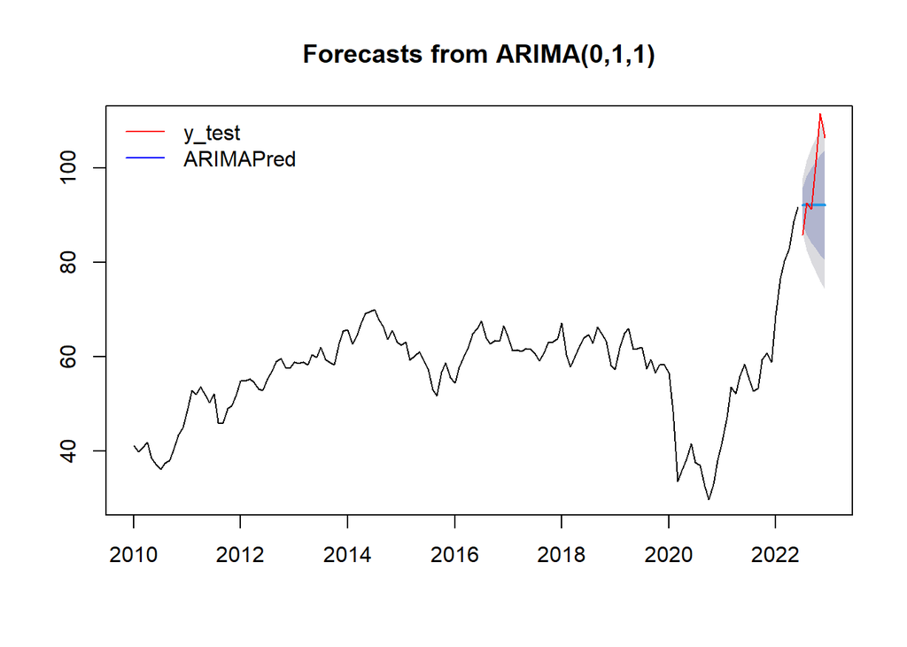

```r
# plot of the prediction and of the test set
#Model 1
mod_1.Fr <- forecast::forecast(mod_1,h=6)
plot(mod_1.Fr)
lines(y_test, col="red")
legend("topleft",lty=1,bty = "n",col=c("red","blue"),c("y_test","ARIMAPred"))
```

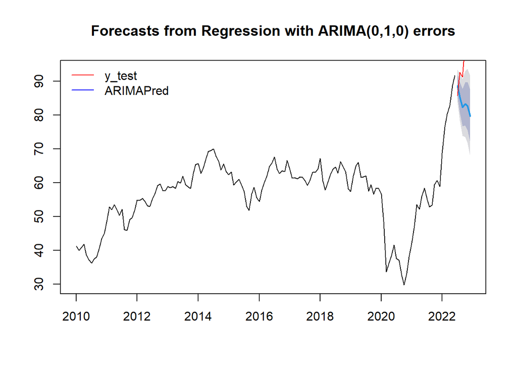

```r
#Model 2
mod_2.Fr <-forecast::forecast(mod_2,xreg = x_test,h=6)
plot(mod_2.Fr)
lines(y_test, col="red")
legend("topleft",lty=1,bty = "n",col=c("red","blue"),c("y_test","ARIMAPred"))
```

### **Using defined ARIMA models**

- Estimate several several ARIMA models(i.e., where $p & q = 0:10$ and $d= 0:1$).
- Start by creating a matrix of all desried order.

```r
#create a matrix of all desired orders
hyper_parameters_df <- expand_grid(p = 0:10, d = 0:1, q=0:10)

#The split() function in R can be used to split data into groups
hyper_parameters_df_list <- split(hyper_parameters_df, seq(nrow(hyper_parameters_df)))
# it is a list, but here its elements are tibbles

hyper_parameters_df <- hyper_parameters_df_list %>% map(lift(c))
# it is also a list, but its elements are vectors

orderdf <- tibble("order" = hyper_parameters_df)
# it is a tibble whose elements are a vector of elements of three compo

nrows <- nrow(orderdf) # number of rows
#glimpse(orderdf)
#View(orderdf)
```

- Setting up a function to extract the point forecast, CI from ARIMA models.

```r
# prepare

# From a forecast object, define point estimate,
# confidence interval and then put all as one data frame

to_tibble <- function(forecast_object){
  point_estimate <-  # set up to extract point estimates from arima model
    forecast_object$mean %>%
    as_tsibble() %>%
    rename(point_estimate = value,
           date = index)

  upper <-  # upper bound for 80% and 95% CI
    forecast_object$upper %>%
    as_tsibble() %>%
    pivot_wider(names_from = "key", # change str from long to wider form
                values_from = "value") %>%
    rename(date = index,
           upper80 = `80%`,
           upper95 = `95%`)

  lower <- forecast_object$lower %>%# upper bound for 80% and 95% CI
    as_tsibble() %>%
    pivot_wider(names_from = "key",
                values_from = "value") %>%
    rename(date = index,
           lower80 = `80%`,
           lower95 = `95%`)
  #put everything as a list
  reduce(list(point_estimate, upper, lower), full_join)
}
```

#### Model 1- Univariate ARIMA model

- Here $y$, which is the the monthly average stock prices for xom is used as a dependent variable.

```r
# Model 1

tic <- Sys.time() # set system initial time
models_df <-
  orderdf %>%
  # apply the model order to ARIMA model using future_map fun.
  mutate(models = future_map(.x = order,
                  # to catch and address potential errors.
                             ~possibly(Arima, otherwise = NULL)(y_train,  order = .x)))

toc <- Sys.time() - tic # time difference
toc
```

```
Time difference of 59.29822 secs
```

```r
# Forecasting, and calculating rmse
models_df <-
  models_df %>%
  #use possibly to return values instead of errors
  mutate(forecast = map(models, ~possibly(forecast, otherwise = NULL)(., h = 6))) %>%
  #using the estimated model for forecasting at y_test
  mutate(point_forecast = map(forecast, ~.$`mean`)) %>%
  mutate(true_value = rerun(nrows, y_test)) %>%
  #calculate the rmse
  mutate(rmse = map2_dbl(point_forecast, true_value,  ~sqrt(mean((as.vector(.x) - as.vector(.y))^2))))
```

```r
# select /filter the order of the best model
best_model <-models_df %>%filter(rmse == min(rmse, na.rm = TRUE))
best_model$order
```

```
$`236`
 p  d  q
10  1  4
```

```r
# forecast using the best model
best_model_forecast <- to_tibble(best_model$forecast[[1]])
best_model_forecast
```

```
# A tsibble: 6 x 6 [1M]
      date point_estimate upper80 upper95 lower80 lower95
     <mth>          <dbl>   <dbl>   <dbl>   <dbl>   <dbl>
1 2022 Jul           92.7    96.6    98.6    88.9    86.9
2 2022 Aug           95.3   102.    105.     89.0    85.6
3 2022 Sep           96.5   105.    109.     88.3    83.9
4 2022 Oct           96.1   106.    111.     86.5    81.3
5 2022 Nov           98.0   109.    115.     87.0    81.2
6 2022 Dec          100.    112.    119.     87.7    81.2
```

```r
#estimate the best arima model based selected optimal order
fit1 <- forecast::Arima(y_train, order=unlist(best_model$order))
summary(fit1)
```

```
Series: y_train
ARIMA(10,1,4)

Coefficients:
          ar1      ar2      ar3     ar4      ar5     ar6     ar7     ar8
      -0.6478  -0.4192  -0.0885  0.4825  -0.0281  0.0949  0.1421  0.0805
s.e.   0.6495   0.7559   0.6562  0.3783   0.1751  0.1246  0.1522  0.1728
          ar9    ar10     ma1     ma2     ma3      ma4
      -0.0351  0.0961  0.9691  0.6609  0.2277  -0.4494
s.e.   0.1430  0.1036  0.6492  0.9576  0.9127   0.5944

sigma^2 = 8.926:  log likelihood = -367.94
AIC=765.88   AICc=769.48   BIC=810.93

Training set error measures:
                    ME     RMSE      MAE       MPE     MAPE      MASE
Training set 0.2281384 2.834379 2.149527 0.2886829 4.038546 0.2298515
                     ACF1
Training set -0.005967615
```

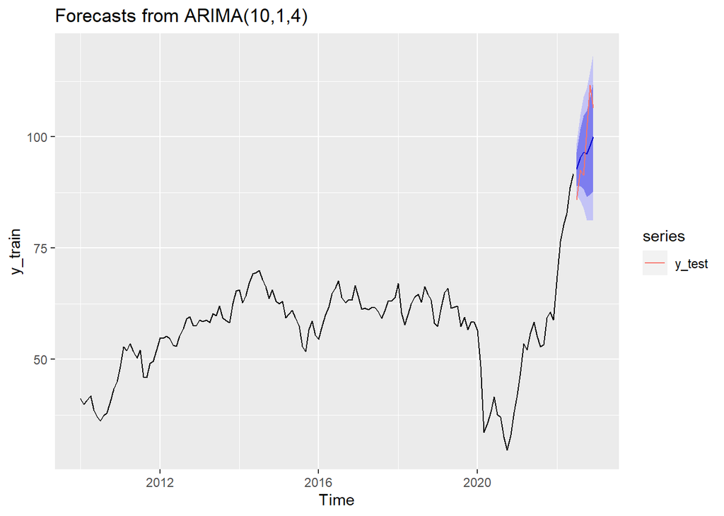

```r
fcst1 <- forecast::forecast(fit1, h=6) # forecasting

autoplot(fcst1) + autolayer(y_test) #ploting
```

```r
# Apply fitted model to later data
fit_test1 <- forecast::Arima(window(y, start=c(2022,7), model=fit1))
```

```r
# Forecast accuracy measures on the log scale.
# in-sample one-step forecasts.
forecast::accuracy(fit1)
```

```
                    ME     RMSE      MAE       MPE     MAPE      MASE
Training set 0.2281384 2.834379 2.149527 0.2886829 4.038546 0.2298515
                     ACF1
Training set -0.005967615
```

```r
# out-of-sample one-step forecasts.
forecast::accuracy(fit_test1)
```

```
                        ME     RMSE      MAE        MPE     MAPE MASE      ACF1
Training set -1.894781e-14 9.037603 8.316715 -0.8480463 8.520607  NaN 0.4892863
```

```r
# out-of-sample multi-step forecasts
forecast::accuracy(forecast(fit1, h=6, lambda=NULL), window(y,start=c(2022,7))) # Model 1
```

```
                    ME     RMSE      MAE       MPE     MAPE      MASE
Training set 0.2281384 2.834379 2.149527 0.2886829 4.038546 0.2298515
Test set     1.7927163 7.519349 6.729471 1.1693969 6.723179 0.7195904
                     ACF1 Theil's U
Training set -0.005967615        NA
Test set      0.448304313 0.9684065
```

#### Model 2- Bivaraite ARIMA Model

- Here, again, $y$, which is the the monthly average stock prices for xom is used as a dependent variable,
- And the the monthly average of Brent Crude Oil Prices is used as $x-$variable.

```r
# Model 2
tic <- Sys.time()
models_df <-
  orderdf %>%
  mutate(models = future_map(.x = order,
                            ~possibly(Arima, otherwise = NULL)(y_train, xreg=x_train, order = .x))) # Model 2

toc <- Sys.time() - tic
toc
```

```
Time difference of 1.176691 mins
```

```r
models_df <-
  models_df %>%
  mutate(forecast = map(models, ~possibly(forecast, otherwise = NULL)(., xreg=x_test, h = 6))) %>% # Model 2
  mutate(point_forecast = map(forecast, ~.$`mean`)) %>%
  mutate(true_value = rerun(nrows, y_test)) %>%
  mutate(rmse = map2_dbl(point_forecast, true_value, ~sqrt(mean((as.vector(.x) - as.vector(.y))^2))))

best_model <-
  models_df %>%
  filter(rmse == min(rmse, na.rm = TRUE))

best_model$order
```

```
$`129`
p d q
5 1 7
```

```r
best_model_forecast <- to_tibble(best_model$forecast[[1]])
```

```r
fit2 <- forecast::Arima(y_train, xreg=x_train, order=unlist(best_model$order)) # Model 2
summary(fit2)
```

```
Series: y_train
Regression with ARIMA(5,1,7) errors

Coefficients:
         ar1      ar2     ar3      ar4     ar5     ma1     ma2     ma3      ma4
      0.3228  -1.0697  0.9653  -0.2423  0.5757  -0.152  1.0002  -0.797  -0.0098
s.e.     NaN      NaN     NaN      NaN  0.0631     NaN     NaN     NaN      NaN
          ma5      ma6     ma7       x
      -0.4043  -0.0676  0.2442  0.2623
s.e.   0.0881   0.0882  0.0889  0.0337

sigma^2 = 6.143:  log likelihood = -340.85
AIC=709.69   AICc=712.83   BIC=751.75

Training set error measures:
                    ME     RMSE      MAE       MPE     MAPE      MASE
Training set 0.1921801 2.360036 1.842171 0.2366317 3.407661 0.1969856
                    ACF1
Training set -0.02427289
```

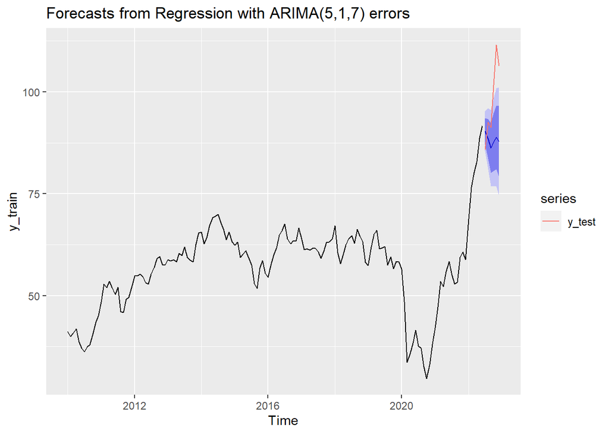

```r
fcst2 <- forecast::forecast(fit2, xreg=x_test, h=6) # Model 2
autoplot(fcst2) + autolayer(y_test)
```

```r
# Apply fitted model to later data
fit_test2 <- forecast::Arima(window(y, start=c(2022,7), model=fit2))
```

```r
# Forecast accuracy measures on the log scale.
# in-sample one-step forecasts.
forecast::accuracy(fit2)
```

```
                    ME     RMSE      MAE       MPE     MAPE      MASE
Training set 0.1921801 2.360036 1.842171 0.2366317 3.407661 0.1969856
                    ACF1
Training set -0.02427289
```

```r
# out-of-sample one-step forecasts.
forecast::accuracy(fit_test2)
```

```
                        ME     RMSE      MAE        MPE     MAPE MASE      ACF1
Training set -1.894781e-14 9.037603 8.316715 -0.8480463 8.520607  NaN 0.4892863
```

```r
# out-of-sample multi-step forecasts
forecast::accuracy(forecast(fit2, xreg=x_test, h=6, lambda=NULL), window(y,start=c(2022,7))) # Model 2
```

```
                    ME      RMSE       MAE       MPE      MAPE      MASE
Training set 0.1921801  2.360036  1.842171 0.2366317  3.407661 0.1969856
Test set     9.9962476 13.663997 11.498357 9.3910677 11.141022 1.2295331
                    ACF1 Theil's U
Training set -0.02427289        NA
Test set      0.48907611  1.852991
```

**The two plots above together**

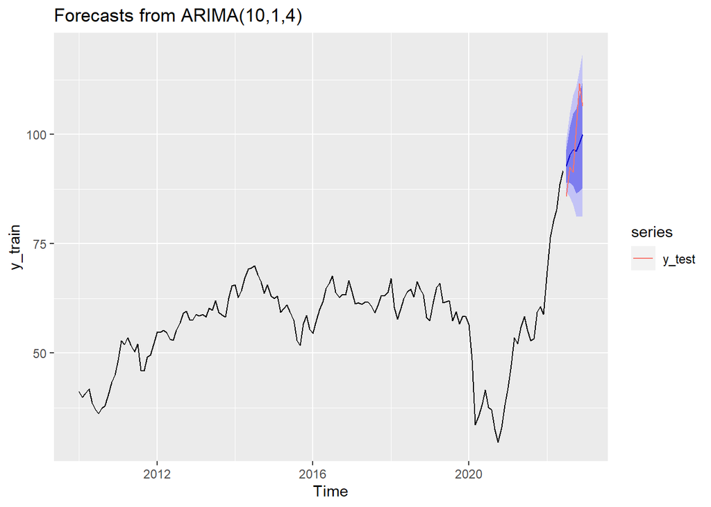

```r
autoplot(fcst1) + autolayer(y_test)
```

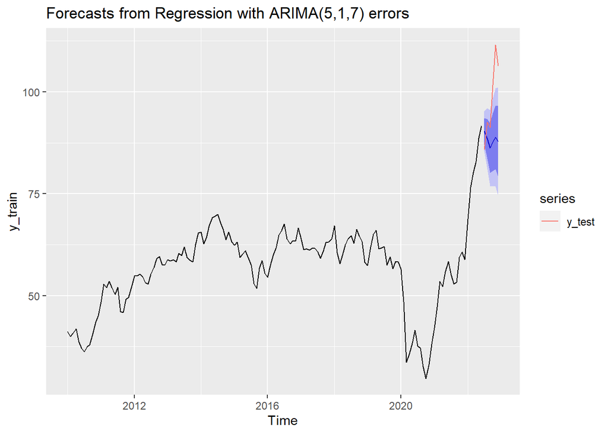

```r
autoplot(fcst2) + autolayer(y_test)
```

## summary from the ARIMA models

- It is clear from the plots that the prediction based on the univariate ARMA model produces a good forecast of the series compared to the bivariate model.
- The reason for this could be (as can be seen from the individual time series plots), within the sample(test data) the XOM price is showing an increasing trend, while the Brent Crude oil price is showing a decreasing trend.
- Furthermore, the best model can be selected based on certain criteria such as MAPE (Mean absolute percentage error). The best model is considered to have the lowest MAPE.
- Generally, for in-sample forecasting, the short order model is preferred models, whereas;
- For out of sample forecasting, the higher order model is the preferred model.Since higher order models consider more lags, getting more information.